# Project 1

ECE 232E Summer 2026 - Project 1: Random Graphs and Random Walks  
Posted: Friday, June 26, 2026  
Due: Sunday, July 12, 2026 at 11:59 PM PST

By Enoch Yeoh 906630606 / Nicolas Jeong Lee 605309755 / James Chen 005399315

## 1. Generating Random Networks

### 1. Create random networks using Erdos-Renyi (ER) model

#### (a)

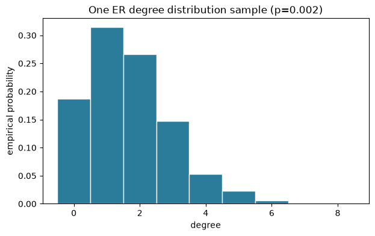

```
empirical mean: 1.6711111111111112
theory mean: 1.798
empirical variance: 1.680720987654321
theory variance: 1.794404
```

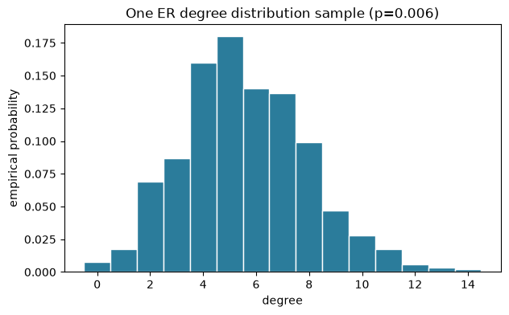

```
empirical mean: 5.5777777777777775
theory mean: 5.394
empirical variance: 5.595061728395062
theory variance: 5.361636
```

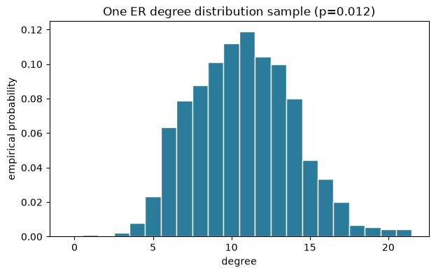

```
empirical mean: 10.751111111111111
theory mean: 10.788
empirical variance: 10.540276543209876
theory variance: 10.658544000000001
```

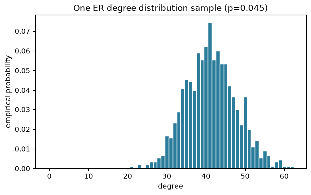

```
empirical mean: 41.291111111111114
theory mean: 40.455
empirical variance: 41.977476543209875
theory variance: 38.634525
```

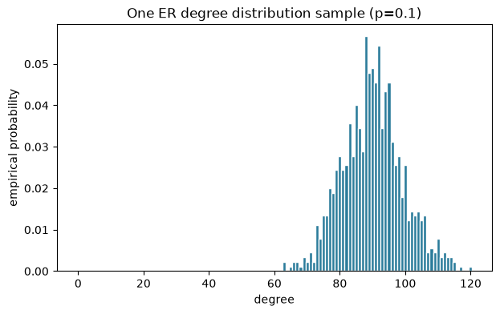

```
empirical mean: 89.98666666666666
theory mean: 89.9
empirical variance: 84.74648888888889
theory variance: 80.91000000000001
```

```python
from project1_code import question_1a
question_1a()
```

#### (b)

```python
from project1_code import question_1b
question_1b()
```

```
p=0.002 P(conn)~0.00, avg GCC frac~0.73, avg GCC diam~25.30
p=0.006 P(conn)~0.00, avg GCC frac~1.00, avg GCC diam~8.20
p=0.012 P(conn)~1.00, avg GCC frac~1.00, avg GCC diam~5.00
p=0.045 P(conn)~1.00, avg GCC frac~1.00, avg GCC diam~3.00
p=0.100 P(conn)~1.00, avg GCC frac~1.00, avg GCC diam~3.00
GCC diameter=24 for a disconnected network (p=0.002) instance
```

#### (c)

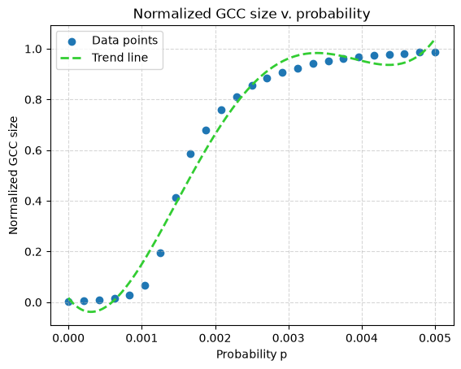

```
First X value above Y > 0.005: 0.00021
Actual Y value at that point: 0.00513
First X value above Y > 0.98: 0.00458
Actual Y value at that point: 0.98163

Part (i) p = 0.00021, gcc_size = 0.00513
Part (ii) p = 0.00458, gcc_size = 0.98163
```

```python
from project1_code import question_1c
question_1c()
```

#### (d)

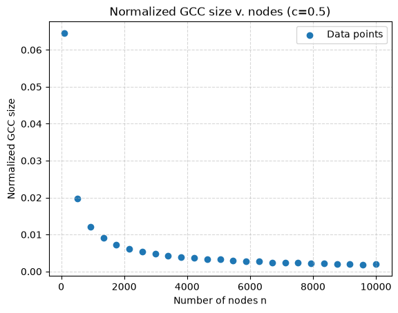

```python
from project1_code import question_1d
question_1d(c=0.5)
```

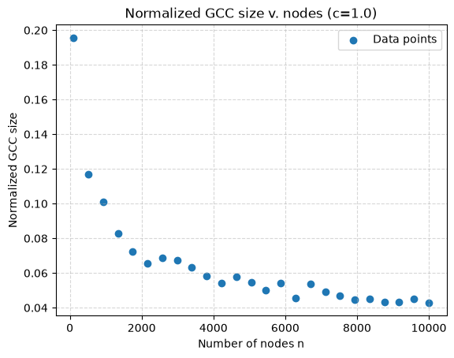

```python
question_1d(c=1.0)
```

ii. The same decreasing exponential trend is observed for c=1, except the GCC size does not approach zero but remains on a higher floor centering 0.04

```
Generating random networks for c=1.15
Generating random networks for c=1.25
Generating random networks for c=1.35
```

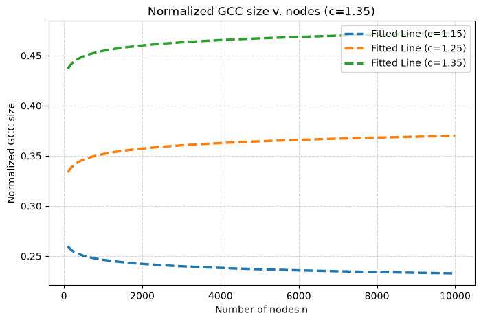

```python
from project1_code import question_1d_part_iv
question_1d_part_iv()
```

iii. See above for c=1.15, 1.25, 1.35 plots.

### 2. Create networks using preferential attachment model

#### (a)

```python
from project1_code import question_2a
question_2a()
```

```
[True, True, True, True, True, True, True, True, True, True, True, True, True, True, True, True, True, True, True, True]
Yes, this network is always connected
```

#### (b)

```python
from project1_code import question_2b
question_2b()
```

```
IGRAPH U--- 1050 1049 --
connected: True
max degree: 24
mean degree: 1.9980952380952381
degree variance: 4.17332970521542
edges: 1049 , assortativity: -0.09135136092382576 , modularity: 0.935
Assortativity is defined as a measure of the tendency for nodes to connect to other nodes with similar properties
Assortativity is positive if similar nodes tend to connect to each other, and negative otherwise
```

#### (c)

```python
from project1_code import question_2c
question_2c()
```

```
IGRAPH U--- 10500 10499 --
connected: True
max degree: 95
mean degree: 1.9998095238095237
degree variance: 5.846476154195011
edges: 10499 , assortativity: -0.03100035425224403 , modularity: 0.979
```

The value of assortativity for a 10500 nodes is slightly less negative and the value of modularity is slightly higher than the one with 1050 nodes. However, the change in value isn't that big to claim that there is a significant difference.

#### (d)

```
Nodes:  1050 , m =  1
rough log-log slope: -2.0998976217006526
```

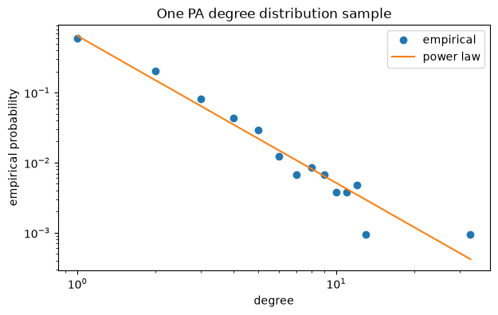

```
Nodes:  10500 , m =  1
rough log-log slope: -2.6111392722663567
```

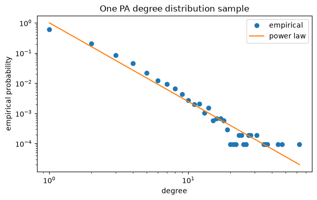

```python
from project1_code import question_2d
question_2d()
```

#### (e)

```
rough log-log slope: -1.2256956531976575
```

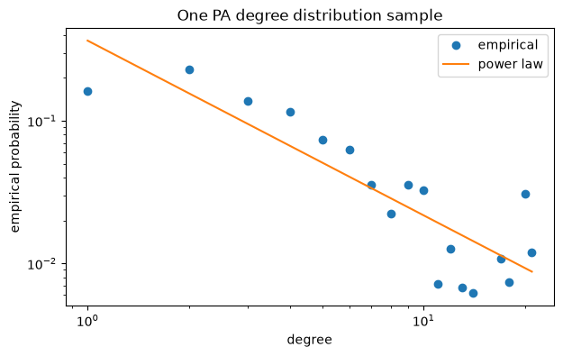

```python
from project1_code import question_2e
question_2e(1050)
```

```
rough log-log slope: -1.4686951209862034
```

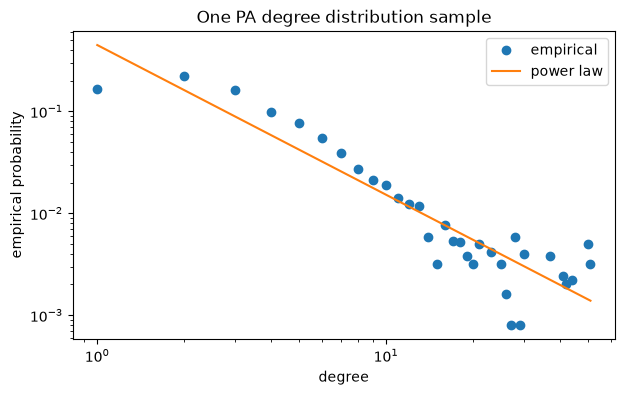

```python
question_2e(10500)
```

The distribution should still be linear since sampling a neighbor of a random node is still fundamentally drawing from a degree-biased version of the same power-law population. That being said, the slope becomes less negative(or less steep) compared to node degree distribution.

#### (f)

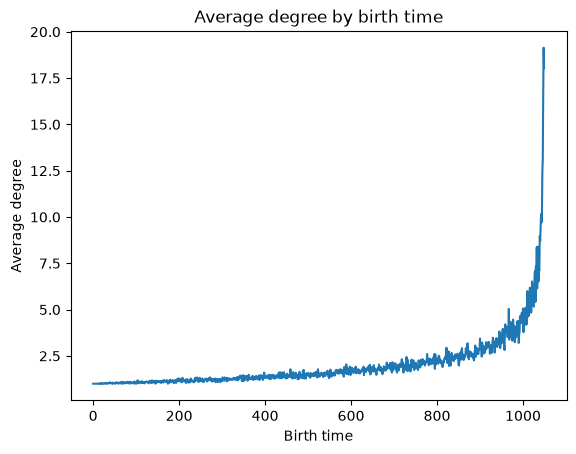

```python
from project1_code import question_2f
question_2f()
```

#### (g)

```
[True, True, True, True, True, True, True, True, True, True, True, True, True, True, True, True, True, True, True, True]
Yes, this network is always connected
IGRAPH U--- 1050 2097 --
connected: True
max degree: 60
mean degree: 3.994285714285714
degree variance: 17.937110204081634
edges: 2097 , assortativity: -0.04381372807349328 , modularity: 0.522
Nodes:  1050 , m =  2
rough log-log slope: -2.177362601647715
```

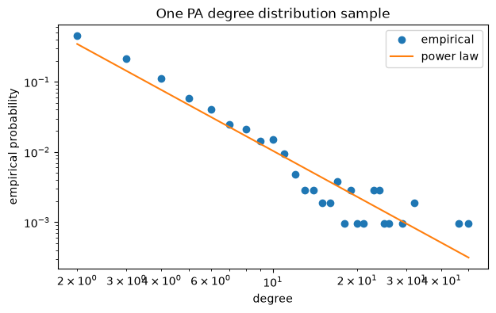

```
rough log-log slope: -1.077340553118729
```

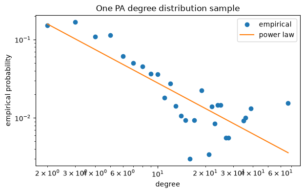

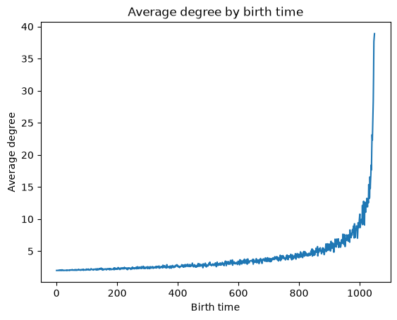

```
IGRAPH U--- 10500 20997 --
connected: True
max degree: 139
mean degree: 3.9994285714285716
degree variance: 23.31619014965986
edges: 20997 , assortativity: -0.010584339608166836 , modularity: 0.532
Nodes:  10500 , m =  2
rough log-log slope: -2.3593799931878996
```

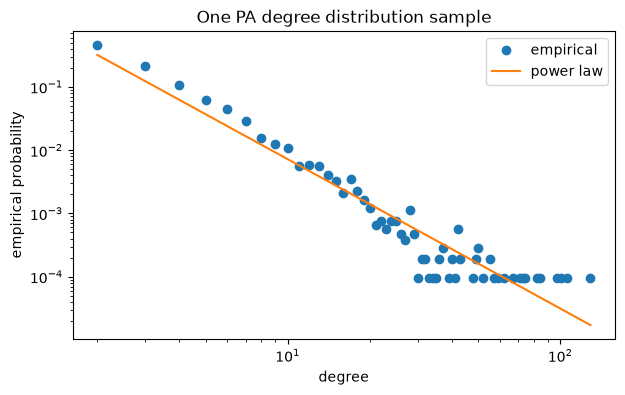

```
rough log-log slope: -1.3391496625798234
```

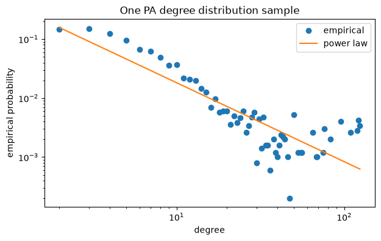

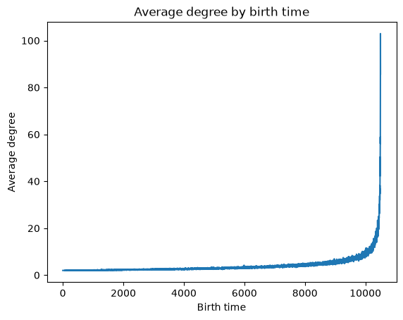

```python
from project1_code import question_2g
question_2g(2)
```

```
[True, True, True, True, True, True, True, True, True, True, True, True, True, True, True, True, True, True, True, True]
Yes, this network is always connected
IGRAPH U--- 1050 6279 --
connected: True
max degree: 119
mean degree: 11.96
degree variance: 126.4841142857143
edges: 6279 , assortativity: -0.012816169789175262 , modularity: 0.245
Nodes:  1050 , m =  6
rough log-log slope: -1.9576576502919065
```

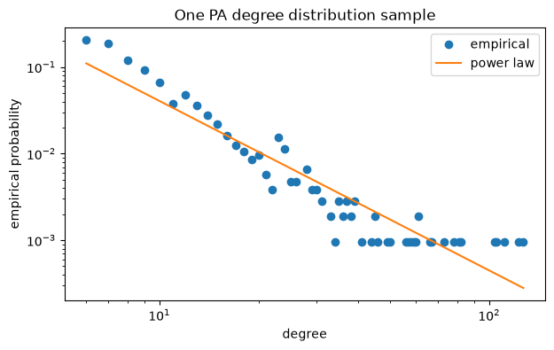

```
rough log-log slope: -0.9781989848926438
```

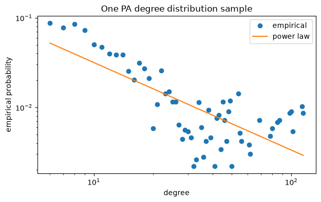

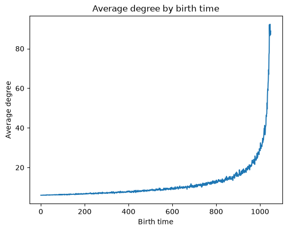

```
IGRAPH U--- 10500 62979 --
connected: True
max degree: 352
mean degree: 11.996
degree variance: 191.6180792380952
edges: 62979 , assortativity: 0.0002519128383233273 , modularity: 0.25
Nodes:  10500 , m =  6
rough log-log slope: -2.1113083355986917
```

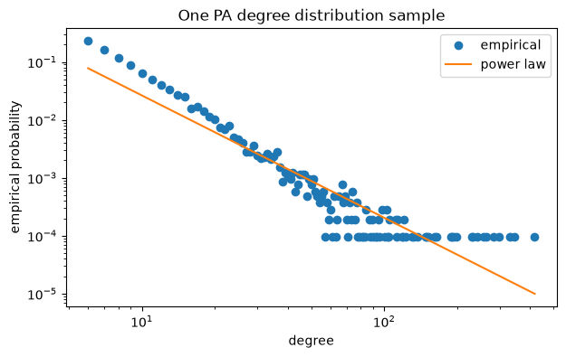

```
rough log-log slope: -1.1682994301888403
```

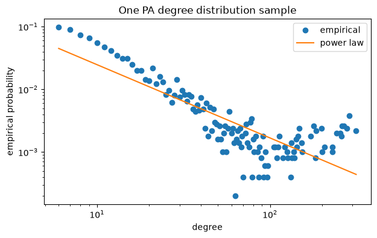

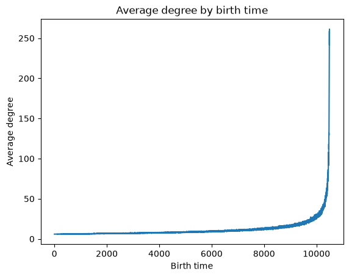

```python
question_2g(6)
```

Main observations noted looking at PA networks with different values of m:

- Modularity decreases as m increases
- Assortativity value is close to 0 regardless of the value of m
- Mean degree increases as m increases
- Plotting the degree distribution of nodes in log-log scale still shows a linear distribution with a slope of around -2 regardless of the value of m
- Randomly picking a node i and getting the degree of nodes of one if its neighbor j, also shows a linear distribution with a less negative(or less steep) slope regardless of the value of m.

#### (h)

```
Original Network
Used Fastgreedy
Modularity:  0.93
```

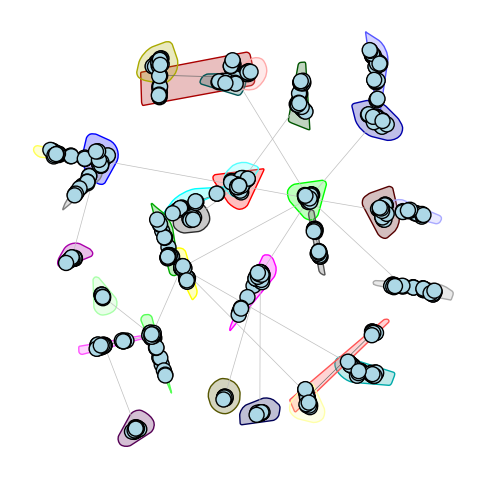

```
IGRAPH U--- 1050 1049 --
connected: True
max degree: 37
mean degree: 1.9980952380952381
degree variance: 6.457139229024944
edges: 1049 , assortativity: -0.09904526728278162

New Network
Fastgreedy failed (Error at src/community/fast_modularity.c:652: Fast greedy community detection works only on graphs without multi-edges. -- Invalid value), Using Walktrap
Modularity:  0.721
```

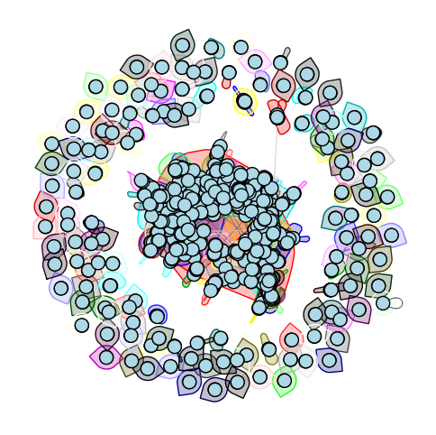

```
IGRAPH U--- 1050 1049 --
connected: False
max degree: 37
mean degree: 1.9980952380952381
degree variance: 6.457139229024944
edges: 1049 , assortativity: 0.03185862710335647
```

```python
from project1_code import question_2h
question_2h()
```

Comparison:

- Stub-matching network has a lower modularity than PA method
- Stub-matching network is also not connected whereas PA is
- PA network has a negative assortativity, while Stub-matching network is positive(and closer to 0)

### 3. Create a modified preferential attachment model that penalizes the age of a node

```
Part A
rough log-log slope: -2.421816596606091
Power Law Exponent is roughly:  2.421816596606091
```

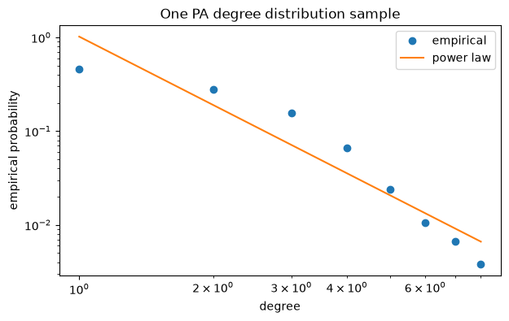

```
Part B
Modularity:  0.936
```

```python
from project1_code import question_3
question_3()
```

## 2. Random Walk on Networks

```
 (a) Generate ER graph with N = 900

Nodes     : 900
Edges     : 6062
Diameter  : 5
Simulating 2000 random walk trials
```

```
 (b) Average distance and variance
```

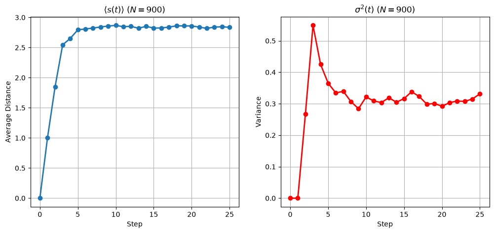

```
 (c) Degree distribution comparison
```

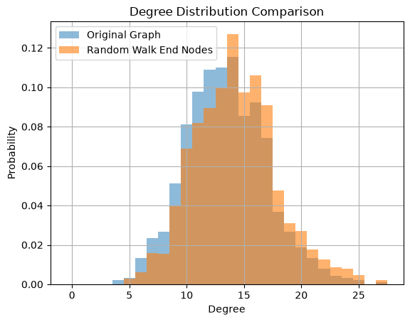

[output not shown]

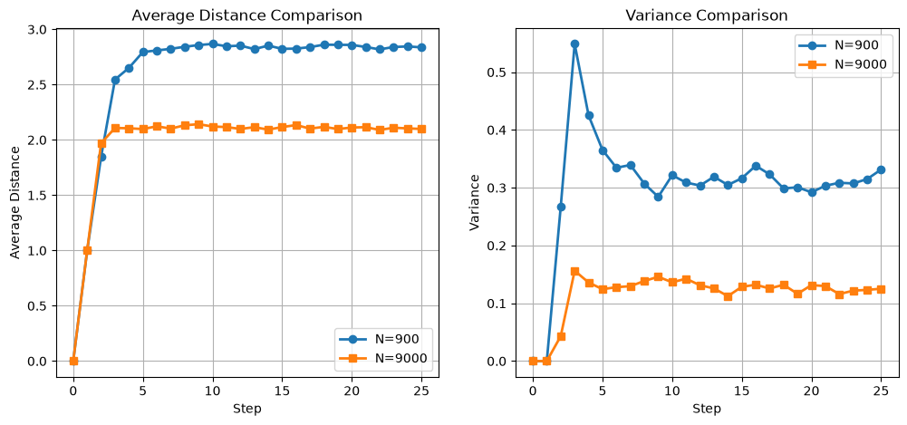

[output not shown]

```python
from project1_code import question2_1
question2_1()
```